# BART Fare Formula

Timothy Sweetser

January 7, 2015

This script reads in a data file containing driving distances and fares between every pair of stations served by Bay Area Rapid Transit, as of January 1, 2013. * Self and Airport are indicator variables * Self = 1 if and only if From Station = To Station * Airport = 1 if and only if San Francisco International Airport is the To or From Station * I assume Fare is symmetric, so that traveling from Station A to Station B costs the same as B to A * SanMateo == 1 iff the trip is To or From Daly City, Colma, South San Francisco, San Bruno or Millbrae * SFO airport might be in San Mateo county, but I already have a surcharge built in for SFO trips * http://sites.google.com/site/tsweetser

```r
setwd('/Users/timothysweetser/Box Sync/BART Project')
BART.raw <- read.csv("data/bart/BART all possible trips.csv")
source("distance correct.R")
BART.raw <- dist_correct(BART.raw)

# include each trip (one pair of stations) only once
keepers <- NULL
for (i in 1: nrow(BART.raw)) {
  sister.row <- intersect(which(BART.raw$To == BART.raw$From[i]),
                      which(BART.raw$From == BART.raw$To[i]))
  keepers <- c(keepers,min(i,sister.row,na.rm=T))
}
rm(i)
BART.fares <- BART.raw[unique(keepers), ]

# fit a linear regression model
mat <- lm(Fare ~ 0 + Miles2 + Airport*TransBay + SanMateo*TransBay,
          # Airport:SanMateo is all 1's
          data=BART.fares,
          offset=rep(1.75,nrow(BART.fares)))
```

None of these interaction terms are significant at 5%: Miles2:TransBay, Miles2:Airport, Miles2:SanMateo. This means the per-mile rate is the same throughout the system.  
The Millbrae-SFO trip has an extremely large, negative residual. How much do the coefficients change by excluding it?

```r
summary(lm(Fare ~ 0 + Miles2 + Airport*TransBay + SanMateo*TransBay,
           data=BART.fares, offset=rep(1.75,nrow(BART.fares)),
           subset=BART.fares$Station.Pair.ID != 1110))
```

```
##
## Call:
## lm(formula = Fare ~ 0 + Miles2 + Airport * TransBay + SanMateo *
##     TransBay, data = BART.fares, subset = BART.fares$Station.Pair.ID !=
##     1110, offset = rep(1.75, nrow(BART.fares)))
##
## Residuals:
##      Min       1Q   Median       3Q      Max
## -1.43966 -0.21959 -0.05958  0.13310  1.14249
##
## Coefficients:
##                     Estimate Std. Error t value Pr(>|t|)
## Miles2             0.0847853  0.0005917  143.30   <2e-16 ***
## Airport            5.0947537  0.0849486   59.98   <2e-16 ***
## TransBay           0.7706546  0.0232520   33.14   <2e-16 ***
## SanMateo           0.8680427  0.0418444   20.75   <2e-16 ***
## Airport:TransBay  -1.0916088  0.1019796  -10.70   <2e-16 ***
## TransBay:SanMateo -1.0738091  0.0515151  -20.84   <2e-16 ***
## ---
## Signif. codes:  0 '***' 0.001 '**' 0.01 '*' 0.05 '.' 0.1 ' ' 1
##
## Residual standard error: 0.2934 on 939 degrees of freedom
## Multiple R-squared:  0.9956, Adjusted R-squared:  0.9956
## F-statistic: 3.533e+04 on 6 and 939 DF,  p-value: < 2.2e-16
```

- Aiport increases from 4.84 to 5.09
- Airport:TransBay decreases from -0.84 to -1.09
- Use this mask to color-code trips

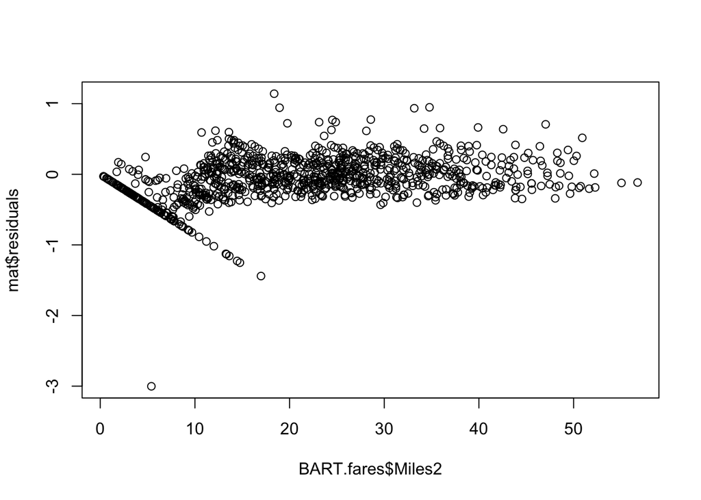

```
## integer(0)
```

```r
transbay.mask <- BART.fares$TransBay == 1
airport.mask <- BART.fares$Airport == 1

plot(x=BART.fares$Miles2, y=mat$residuals)
identify(x=BART.fares$Miles2, y=mat$residuals)
```

Outliers include 911 (San Bruno - SFO), and 921 (SFO - South SF), and SFO - Millbrae.  
Can the model figure out the intercept on its own?

```r
m.int <- lm(Fare ~ Miles + Airport + TransBay, data=BART.fares)
```

First Graph: just the data

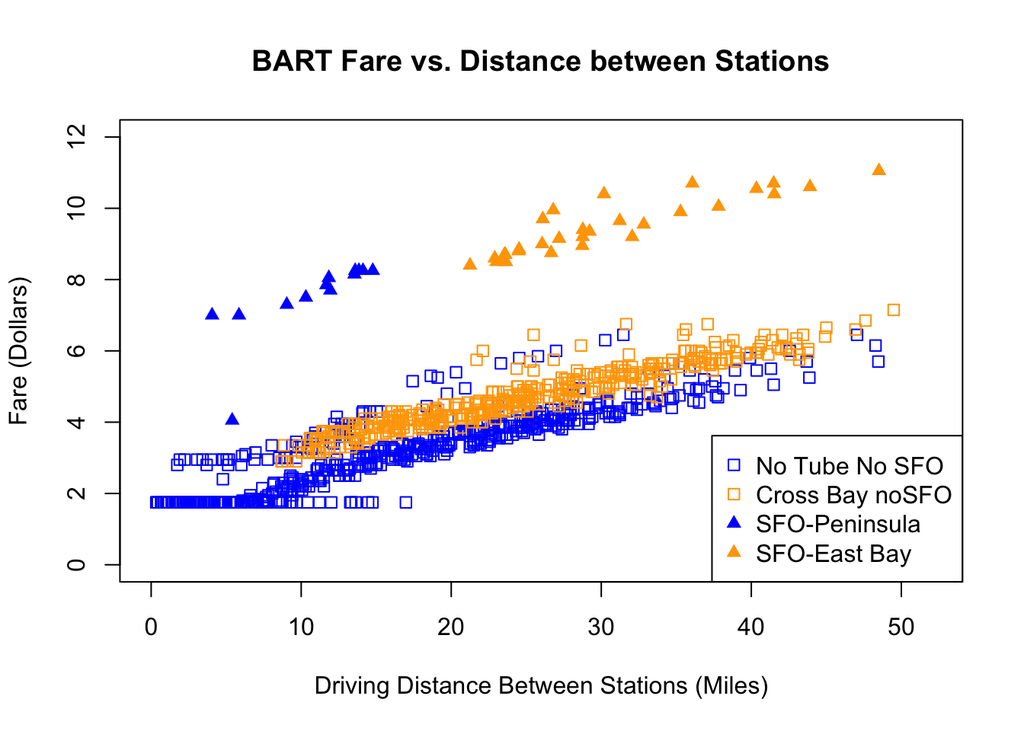

```r
# non airport, non transbay
plot(BART.fares[!transbay.mask & !airport.mask, 'Miles'],
     BART.fares[!transbay.mask & !airport.mask, 'Fare'],
     col="blue", xlab = "Driving Distance Between Stations (Miles)",
     ylab= "Fare (Dollars)", xlim=c(0, 52), ylim=c(0, 12),
     main="BART Fare vs. Distance between Stations", pch=0)
# non-airport, transbay
points(BART.fares[transbay.mask & !airport.mask, 'Miles'],
       BART.fares[transbay.mask & !airport.mask, 'Fare'],
       col="orange", pch=0)
# airport, non transbay
points(BART.fares[!transbay.mask & airport.mask, 'Miles'],
       BART.fares[!transbay.mask & airport.mask, 'Fare'],
       col="blue", pch=17)
# airport, transbay
points(BART.fares[transbay.mask & airport.mask, 'Miles'],
       BART.fares[transbay.mask & airport.mask, 'Fare'],
       col="orange", pch=17)
 # blue = non-transbay, orange=transbay
# pch0=square = non-airport. pch17=triangle=airport
legend(x="bottomright", legend=c('No Tube No SFO',
                                 'Cross Bay noSFO',
                                 'SFO-Peninsula',
                                 'SFO-East Bay'),
       col=rep(c("blue", "orange"), 2), pch=c(0, 0, 17, 17))
```

Now add regression lines.

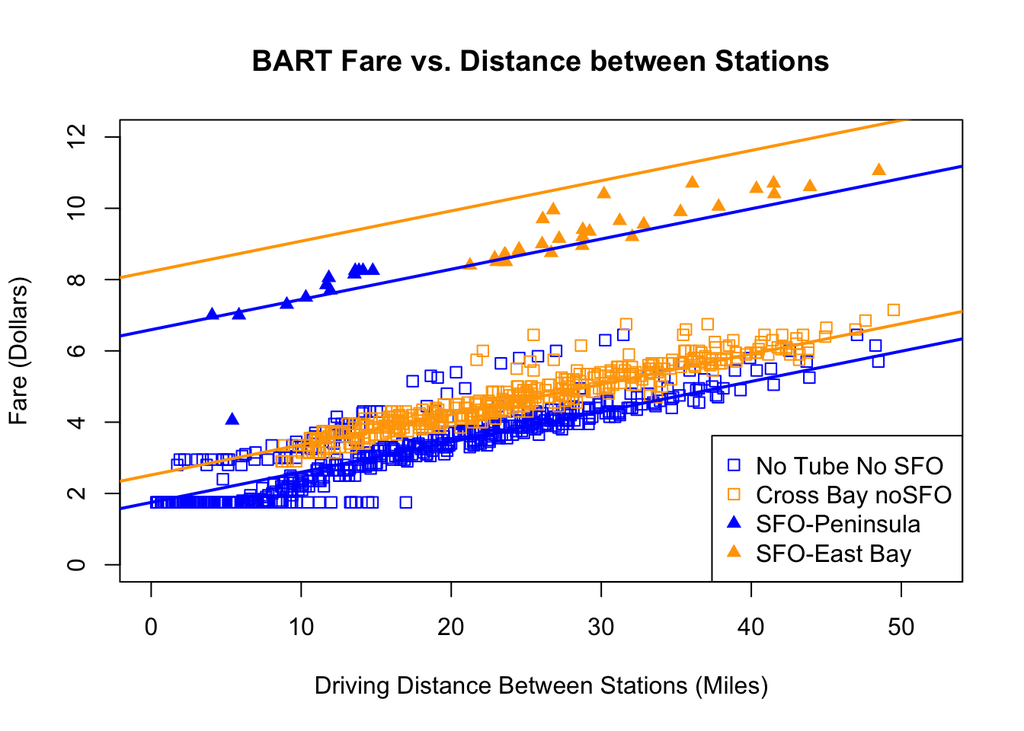

```r
plot(BART.fares[!transbay.mask & !airport.mask, 'Miles'],
     BART.fares[!transbay.mask & !airport.mask, 'Fare'],
     col="blue", xlab = "Driving Distance Between Stations (Miles)",
     ylab= "Fare (Dollars)", xlim=c(0, 52), ylim=c(0, 12),
     main="BART Fare vs. Distance between Stations", pch=0)
# non-airport, transbay
points(BART.fares[transbay.mask & !airport.mask, 'Miles'],
       BART.fares[transbay.mask & !airport.mask, 'Fare'],
       col="orange", pch=0)
# airport, non transbay
points(BART.fares[!transbay.mask & airport.mask, 'Miles'],
       BART.fares[!transbay.mask & airport.mask, 'Fare'],
       col="blue", pch=17)
# airport, transbay
points(BART.fares[transbay.mask & airport.mask, 'Miles'],
       BART.fares[transbay.mask & airport.mask, 'Fare'],
       col="orange", pch=17)
# blue = non-transbay, orange=transbay
# pch0=square = non-airport. pch17=triangle=airport
legend(x="bottomright", legend=c('No Tube No SFO',
                                 'Cross Bay noSFO',
                                 'SFO-Peninsula',
                                 'SFO-East Bay'),
       col=rep(c("blue", "orange"), 2), pch=c(0, 0, 17, 17))

abline(a=1.75, b=coef(mat)[1], lwd=2, col="blue") # no tube, no airport
abline(a=coef(mat)[3] + 1.75, b=coef(mat)[1], lwd=2,
       col="orange") #tube, no airport
abline(a=coef(mat)[2] + 1.75, b=coef(mat)[1], lwd=2,
       col="blue") #no tube, airport
abline(a=sum(coef(mat)[2:4]) + 1.75, b=coef(mat)[1], lwd=2,
       col="orange") #tube, airport
```

SFO outlier is Millbrae-SFO trip. Fare = 4.05

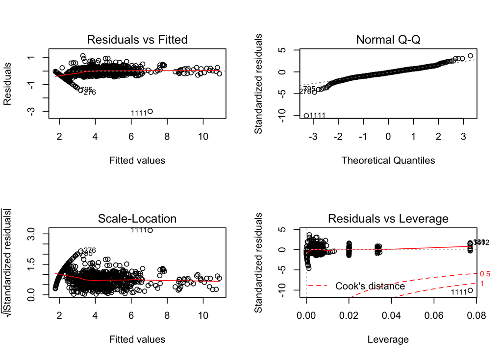

```r
# Residuals
# Airport-only model
par(mfrow=c(2, 2))
plot(mat)
```